# Big Five Personality Traits

## Introduction

The purpose of this project is to elevate the big five personality traits (Openness to experience, Conscientiousness, Extraversion, Agreeableness, Neuroticism) https://www.verywell.com/the-big-five-personality-dimensions-2795422. In relation to gender difference between males and females.

The second part of this project is to look at the differences between males and females and investigate whether there is a significant difference.

The third part of this project will look at the relationship between race, gender and personailty traits.

The fouth part of this project will look at the relationship between participants dominant hand, gender and personailty trait.

This data comes from the Open Source Psychometrics Project (https://openpsychometrics.org).

This dataset consists of 19720 participants (11985 females and 7608 males).

Raw file http://openpsychometrics.org/_rawdata/BIG5.zip

Website https://openpsychometrics.org/tests/IPIP-BFFM/

```r
library(ggplot2)
library(car)
library(dplyr)
set.seed(101)
pd <- read.delim("~/Downloads/BIG5/data.csv", header= TRUE)
pd <- na.omit(pd)
head(pd)
```

|  | race | age | engnat | gender | hand | source | country | E1 | E2 | E3 | E4 | E5 | E6 | E7 | E8 | E9 | E10 | N1 | N2 | N3 | N4 | N5 | N6 | N7 | N8 | N9 | N10 | A1 | A2 | … |
| --- | --- | --- | --- | --- | --- | --- | --- | --- | --- | --- | --- | --- | --- | --- | --- | --- | --- | --- | --- | --- | --- | --- | --- | --- | --- | --- | --- | --- | --- | --- |
| 1 | 3 | 53 | 1 | 1 | 1 | 1 | US | 4 | 2 | 5 | 2 | 5 | 1 | 4 | 3 | 5 | 1 | 1 | 5 | 2 | 5 | 1 | 1 | 1 | 1 | 1 | 1 | 1 | 5 | … |
| 2 | 13 | 46 | 1 | 2 | 1 | 1 | US | 2 | 2 | 3 | 3 | 3 | 3 | 1 | 5 | 1 | 5 | 2 | 3 | 4 | 2 | 3 | 4 | 3 | 2 | 2 | 4 | 1 | 3 | … |
| 3 | 1 | 14 | 2 | 2 | 1 | 1 | PK | 5 | 1 | 1 | 4 | 5 | 1 | 1 | 5 | 5 | 1 | 5 | 1 | 5 | 5 | 5 | 5 | 5 | 5 | 5 | 5 | 5 | 1 | … |
| 4 | 3 | 19 | 2 | 2 | 1 | 1 | RO | 2 | 5 | 2 | 4 | 3 | 4 | 3 | 4 | 4 | 5 | 5 | 4 | 4 | 2 | 4 | 5 | 5 | 5 | 4 | 5 | 2 | 5 | … |
| 5 | 11 | 25 | 2 | 2 | 1 | 2 | US | 3 | 1 | 3 | 3 | 3 | 1 | 3 | 1 | 3 | 5 | 3 | 3 | 3 | 4 | 3 | 3 | 3 | 3 | 3 | 4 | 5 | 5 | … |
| 6 | 13 | 31 | 1 | 2 | 1 | 2 | US | 1 | 5 | 2 | 4 | 1 | 3 | 2 | 4 | 1 | 5 | 1 | 5 | 4 | 5 | 1 | 4 | 4 | 1 | 5 | 2 | 2 | 2 | … |

The scores for each of the five traits need to be summed into a new total score.

There are four different variables used for gender (1=Male, 2=Female, 3=Other 0=missed). This project is only looking at males and females, the other two variables (Other and missed) were removed using the subset function.

```r
pd$Extraversion  <- rowSums(pd[ ,8:17])
pd$Neuroticism  <- rowSums(pd[ ,18:27])
pd$Agreeableness  <- rowSums(pd[ ,28:37])
pd$Conscientiousness  <- rowSums(pd[ ,38:47])
pd$Openness  <- rowSums(pd[ ,48:57])
```

```r
female <- subset(pd, pd$gender == "2")
male <- subset(pd, pd$gender == "1")
pd <- rbind(female, male)
```

```r
pd$Sex <-car::recode(pd$gender, "1 ='M'; 2 ='F'")
```

## Gender difference in personality

These five density plots show personality differences between males and females. The blue overlay is male and the red overlay is female.

The lines on each graph represent the mean score (Males are blue and Females are red). Note: higher or lower score on each item do not signify positive or negative traits.

### Openness to experience

Openness to experience is a trait associated with insight, imagination, creativity and adventure.

https://www.psychologistworld.com/influence-personality/openness-to-experience-trait

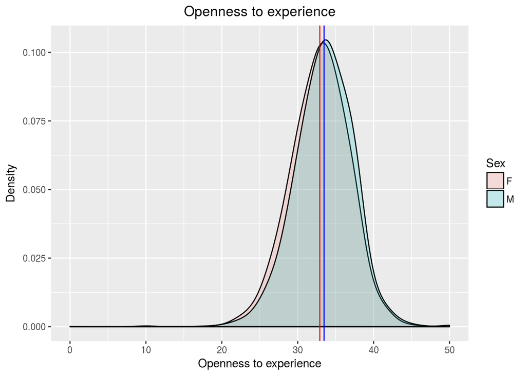

### Conscientiousness

Conscientiousness is a personality trait associated with thoughtfulness, impulse control and goal-directed behaviour.

https://www.psychologistworld.com/influence-personality/conscientiousness-personality-trait

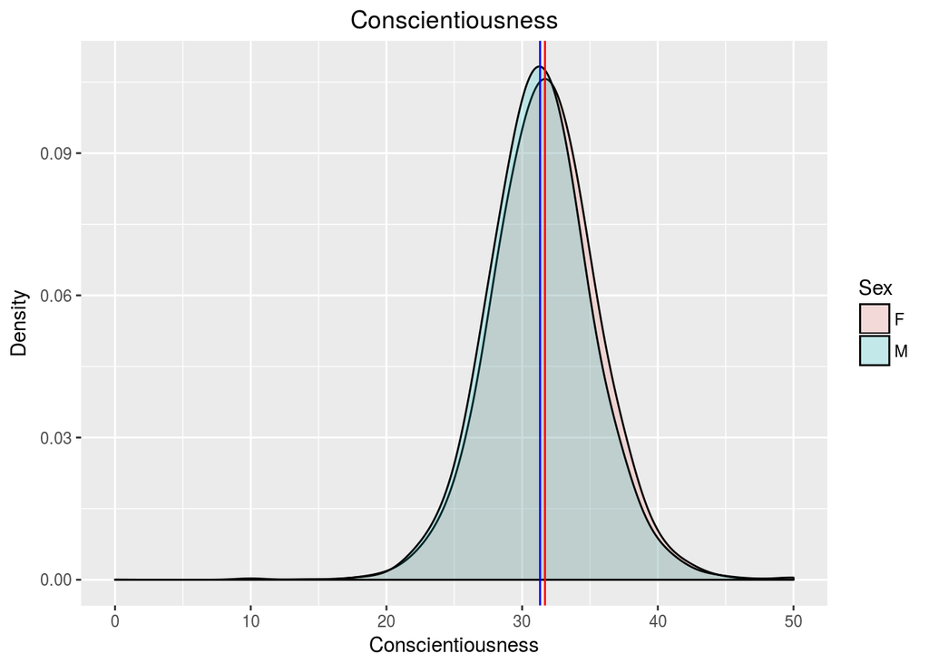

### Extraversion

Extraversion is a personality trait that is associated with assertiveness, emotional, expression, talkative, sociable and excitability.

https://www.psychologistworld.com/influence-personality/extraversion-introversion

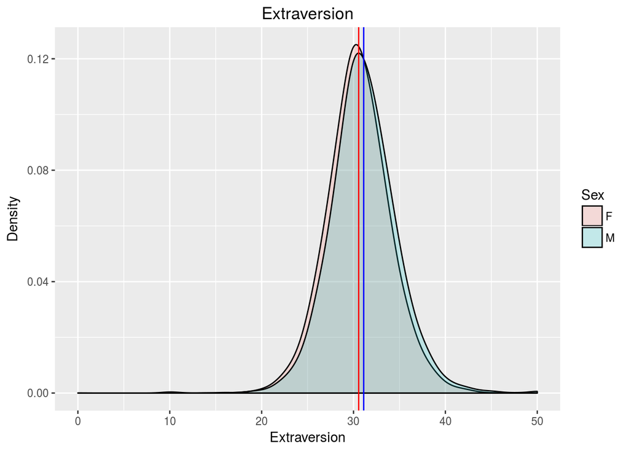

### Agreeableness

Agreeableness is a personality trait that is associated with trust, kindness and affection.

https://www.psychologistworld.com/personality/agreeableness-personality-trait

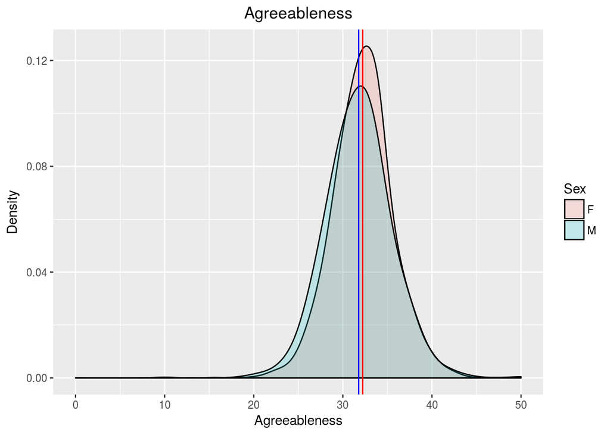

### Neuroticism

Neuroticism is a personality trait that is associated with emotional instability, anxiety, irritability and sadness.

https://www.psychologistworld.com/personality/neuroticism-personality-trait

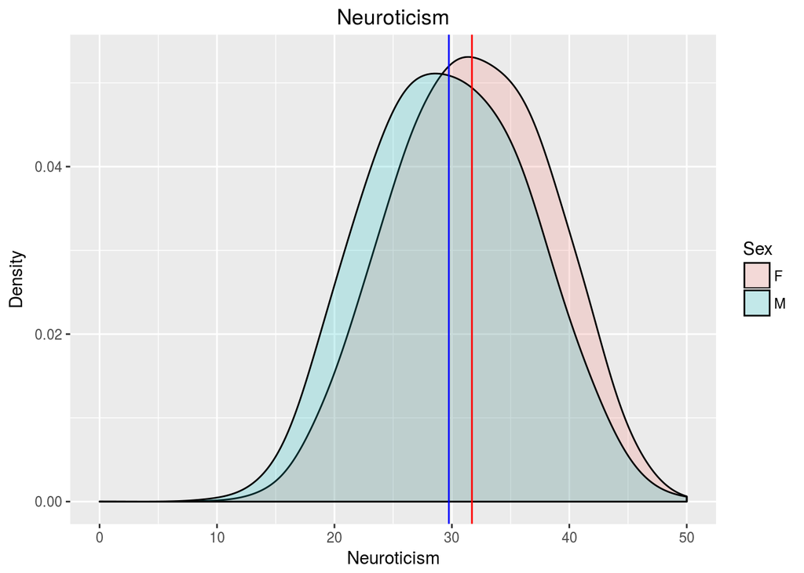

This data shows that female had a higher average score for Conscientiousness, agreeableness and Neuroticism. Whereas, males had a higher average score for Openness to experience and Extraversion.

## Race & Personality Traits

The next part of this project looks at the relationship between race, gender and personality trait. The dataset recorded 9 different races were collected Arctic (Siberian, Eskimo), Caucasian(European, Indian, Middle East, North African), Indigenous Australian, Native American, North East Asian (Mongol, Tibetan, Korean Japanese), Pacific (Polynesian, Micronesian), South East Asian (Chinese, Thai, Malay, Filipino), West African, Bushmen, Ethiopian. Two further races where recored Mixed race and Other, finally, some participants choose to not included their race recorded as missing.

### Extraversion

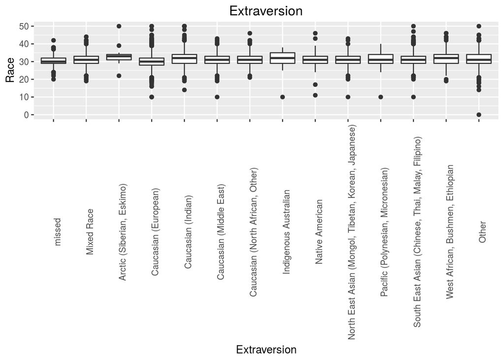

This Barplot indicates that there is little extraversion scores for each of the races. However, based on the scores Caucasian (European) have the lowest levels of extraversion with a mean score of 30.38. Whereas, Arctic (Siberian, Eskimo) scored the highest for extraversion with a mean score of 33.15.

### Neuroticism

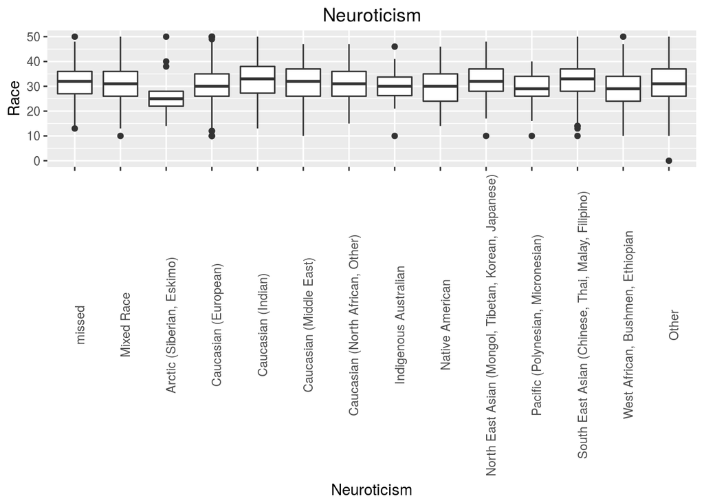

This boxplot indicates that Arctic (Siberian, Eskimo) have the lowest levels of Neuroticism with a mean of 27.46, this would suggest that Arctic (Siberian, Eskimo) have lower levels of anxiety and depression (https://www.psychologytoday.com/us/basics/neuroticism). However, other data suggests that other white Caucasian, Eskimo where the second most lilkey to use mental health services (https://www.samhsa.gov/data/sites/default/files/MHServicesUseAmongAdults/MHServicesUseAmongAdults.pdf)(P1). Whereas, Caucasian (Indian) have the highest levels of Neuroticism with a mean of 32.58.

### Agreeableness

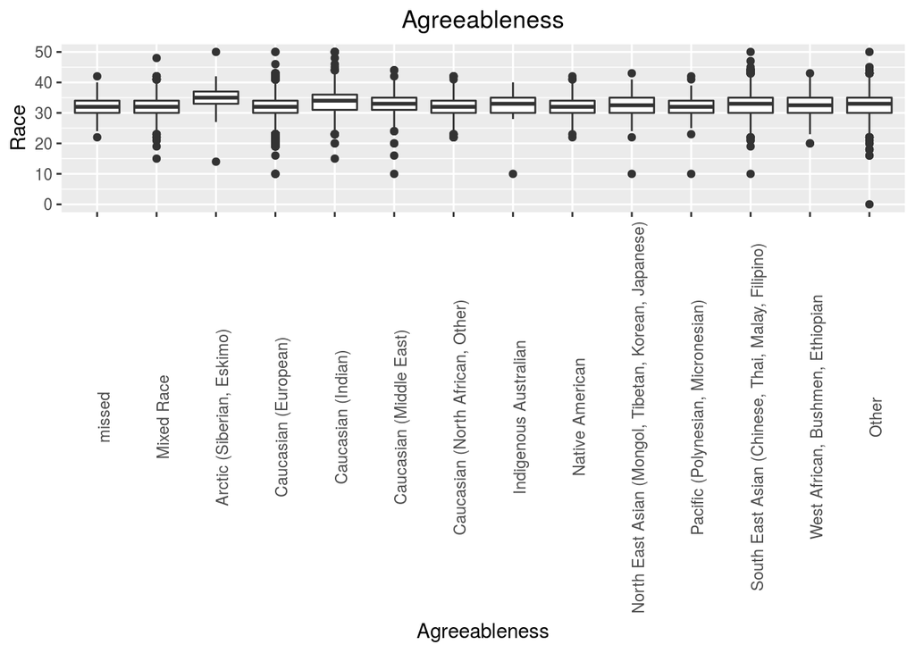

This data indicates that Caucasian (European) have the lowest levels of Agreeableness (31.53). Whereas, Arctic (Siberian, Eskimo) have the highest levels of Agreeableness (34.30)

### Conscientiousness

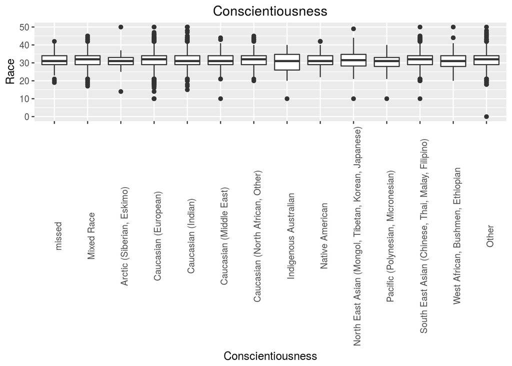

### Openness to experience

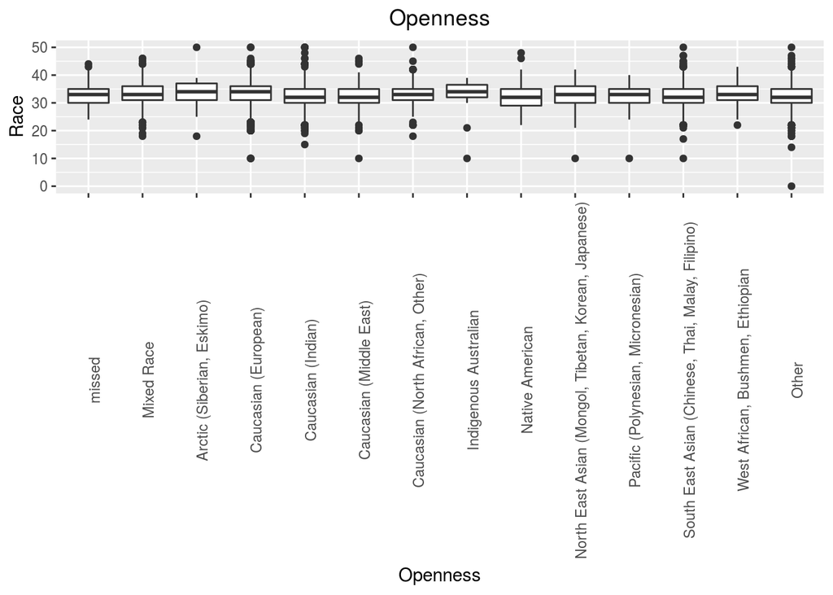

## Personailty Traits & hand preference

This examines the differences between males and females for each of the personality traits in relation to hand preference.

```r
pd$hand <- recode_factor(pd$hand, '0' = "missed",
                         '1' = "Right",
                         '2' = "Left",
                         '3' = "Both")
```

### Extraversion

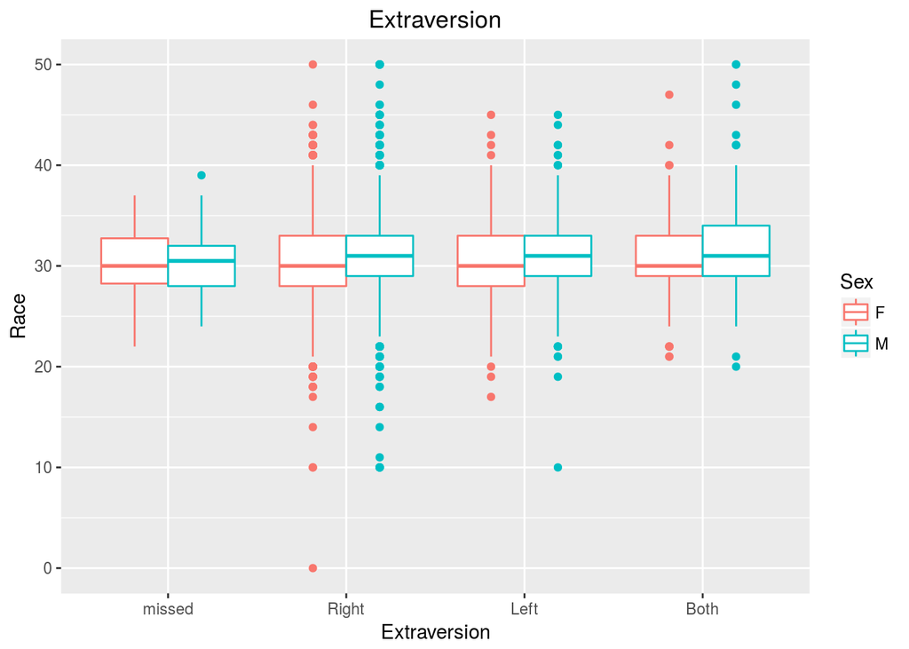

The first boxplot indicates that males scored higher then females for Extraversion. Furthermore, both males and females that had no prefered hand had higher levels of extraversion compared to individuals that had a prefered hand.

### Neuroticism

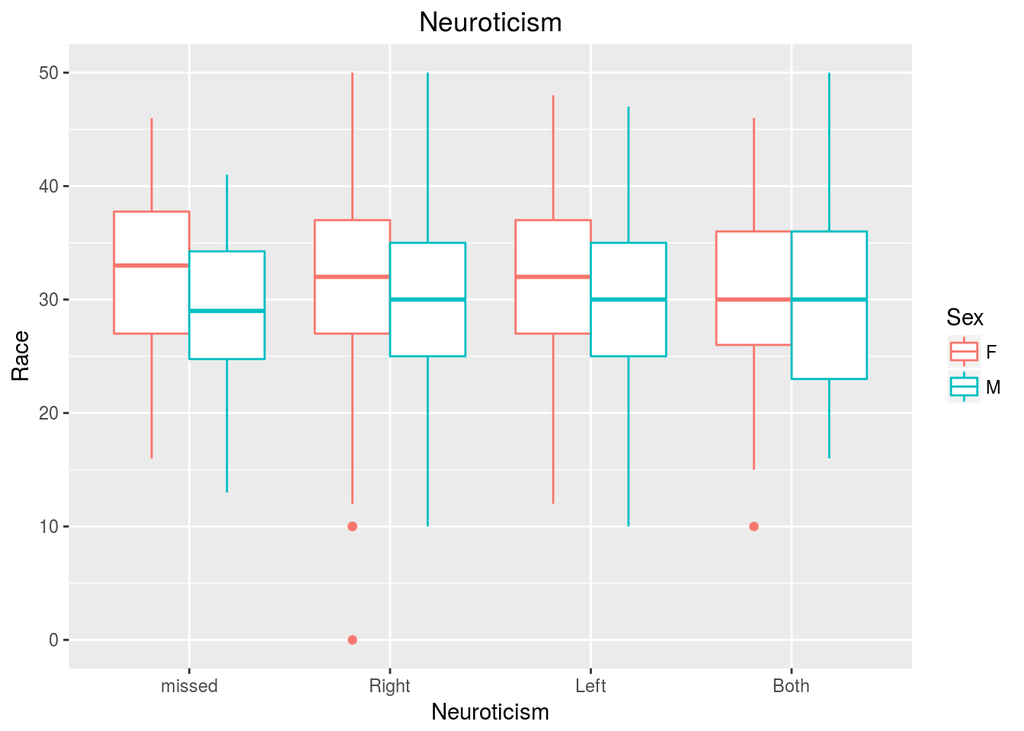

This boxplot indicates that females scored higher then males for Neuroticism. Although, there was no difference between males and females for individuals that had no prefered hand. Furthermore, females that had no prefer hand had the lowest levels of Neuroticism.

### Agreeableness

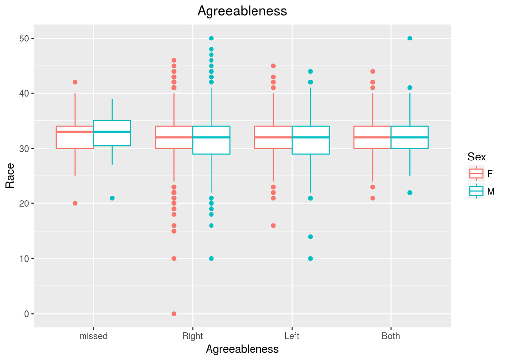

### Conscientiousness

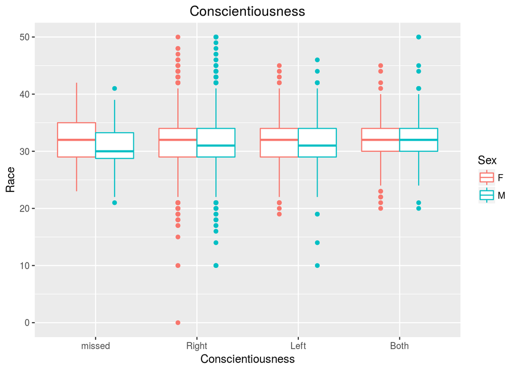

### Openness to experience

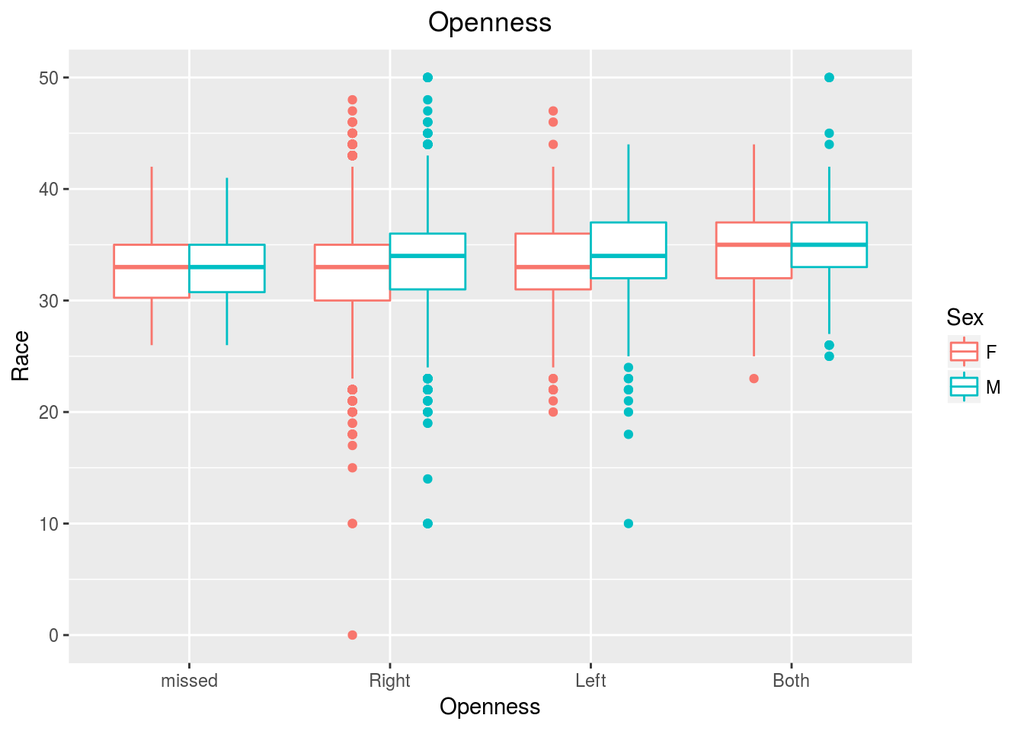

This boxplot indicates that both males and females that had no hand preference scored higher for Openness to experience compared to the other groups, Furthermore there was much overlap between the other three groups.

## Analysis

The second part of this project is to investigate whether the difference displayed in the plots above are significant, Therefore, is there a significant difference between Male and Female personality types?

```r
model <- manova(cbind(Openness, Conscientiousness, Extraversion, Agreeableness, Neuroticism) ~ gender, data = pd)
summary.aov(model)
```

```
##  Response Openness :
##                Df Sum Sq Mean Sq F value    Pr(>F)
## gender          1   1470 1470.07  100.16 < 2.2e-16 ***
## Residuals   19583 287412   14.68
## ---
## Signif. codes:  0 '***' 0.001 '**' 0.01 '*' 0.05 '.' 0.1 ' ' 1
##
##  Response Conscientiousness :
##                Df Sum Sq Mean Sq F value    Pr(>F)
## gender          1    625  624.65  41.588 1.153e-10 ***
## Residuals   19583 294134   15.02
## ---
## Signif. codes:  0 '***' 0.001 '**' 0.01 '*' 0.05 '.' 0.1 ' ' 1
##
##  Response Extraversion :
##                Df Sum Sq Mean Sq F value    Pr(>F)
## gender          1   1391  1391.4  113.09 < 2.2e-16 ***
## Residuals   19583 240936    12.3
## ---
## Signif. codes:  0 '***' 0.001 '**' 0.01 '*' 0.05 '.' 0.1 ' ' 1
##
##  Response Agreeableness :
##                Df Sum Sq Mean Sq F value    Pr(>F)
## gender          1    944  943.75  75.624 < 2.2e-16 ***
## Residuals   19583 244387   12.48
## ---
## Signif. codes:  0 '***' 0.001 '**' 0.01 '*' 0.05 '.' 0.1 ' ' 1
##
##  Response Neuroticism :
##                Df Sum Sq Mean Sq F value    Pr(>F)
## gender          1  18015 18014.8  407.63 < 2.2e-16 ***
## Residuals   19583 865446    44.2
## ---
## Signif. codes:  0 '***' 0.001 '**' 0.01 '*' 0.05 '.' 0.1 ' ' 1
```

This MANOVA model shows that there is a significant difference for each of the five personality types between males and females. This model would indicate that the most significant differences are Extraversion and Neuroticism.